# Data visualisation

Martin Sigrist (21-101-175)

03.06.2023

# Introduction

The aim of this chapter is to tell a story, based on a given data set, that comes with the dataset-R-library.

# Required libraries

```r
# Load required libraries
library(tidyverse)
library(GGally)
library(lubridate)
```

# Data set

The data describes the air quality in New York between May and September 1973 (Chambers et al. 1983). The ozone concentration was obtained from the New York State Department of Conservation. The meteorological data - wind, temperature and solar radiation - come from the National Weather Service.

The data set comprises the following variables:

- Ozone: Mean ozone in parts per billion (ppb) from 1300 to 1500 hours at Roosevelt Island
- Solar.R: Solar radiation in Langleys in the frequency band 4000–7700 Angstroms from 0800 to 1200 hours at Central Park
- Wind: Average wind speed in miles per hour (mph) at 0700 and 1000 hours at LaGuardia Airport
- Temp: Maximum daily temperature in degrees Fahrenheit (°F) at LaGuardia Airport.
- Month: numeric month (1–12)
- Day: numeric day of month (1–31)

```r
# Show first 10 rows of the data set
head(airquality, 10) |>
  knitr::kable(format = "html") |>
  kableExtra::kable_classic(full_width = F)
```

| Ozone | Solar.R | Wind | Temp | Month | Day |
| --- | --- | --- | --- | --- | --- |
| 41 | 190 | 7.4 | 67 | 5 | 1 |
| 36 | 118 | 8.0 | 72 | 5 | 2 |
| 12 | 149 | 12.6 | 74 | 5 | 3 |
| 18 | 313 | 11.5 | 62 | 5 | 4 |
| NA | NA | 14.3 | 56 | 5 | 5 |
| 28 | NA | 14.9 | 66 | 5 | 6 |
| 23 | 299 | 8.6 | 65 | 5 | 7 |
| 19 | 99 | 13.8 | 59 | 5 | 8 |
| 8 | 19 | 20.1 | 61 | 5 | 9 |
| NA | 194 | 8.6 | 69 | 5 | 10 |

# Ozone formation

The ozone formation in the earths atmosphere occurs by a combination reaction of atomic oxygen (O) and molecular oxygen (O<sub>2</sub>) (Wang et al., 2017, p. 1583). In the stratosphere as well as in the troposphere, ozone formation requires solar radiation. Because of the absence of short-wavelength ultraviolet (UV) radiation in the lowest layers of the atmosphere, on ground level, ozone is only formed in combination with other chemical species (ibid.). In combination with nitrogen oxide (NO<sub>2</sub>) the process is called No<sub>X</sub>-cycle. A second process is called organic peroxy radical (RO<sub>2</sub>)-cycle and happens when volatile organic compounds are present (ibid.).

# Hypothesis

The well understood ozone formation process can explain, why ozone concentration on ground level is the highest in urban areas during summer months. The available data will be used to verify or reject the following hypothesis:

- As higher the solar radiation, the higher is the ozone concentration.

Air pollution is involved in the ozone formation process. A second hypothesis can be framed:

- Days with stronger wind will have lower ozone concentration, because air pollution is diluted by air exchange

# Data conversion

Measurement values in the data set are not in SI units. In a first step, they are converted into SI units by the following conversion factors, provided by the National Institute of Standards and Technology (NIST 2016):

|  | To convert from | to | Multiply by |
| --- | --- | --- | --- |
| Density of energy | langley (cal<sub>th</sub>∙cm<sup>-2</sup>) | joule per square meter (J∙m<sup>-2</sup>) | 4.184∙10<sup>4</sup> |
| Temperature | degree Fahrenheit (°F) | degree Celsius (°C) | t/°C = (t/°F - 32)/1.8 |
| Velocity | mile per hour (mi∙h<sup>-1</sup>) | meter per second (m∙s<sup>-1</sup>) | 4.4704∙10<sup>-1</sup> |

```r
# Convert units from data set into SI-units and add a new column with date-time object
airquality_SI <-
  airquality |>
    mutate(Solar.R = Solar.R * 4.184e04, # Solar radiation in J/m^2
           Wind = Wind * 4.4704e-01,     # Wind speed in m/s
           Temp = (Temp - 32)/1.8,       # Temperature in °C
           date = ymd(
             paste("1973-",
                   as.character(Month),
                   as.character(Day)))
           )
```

# Temporal patterns

Plotting the measured values against the time, gives am overview about the available data.

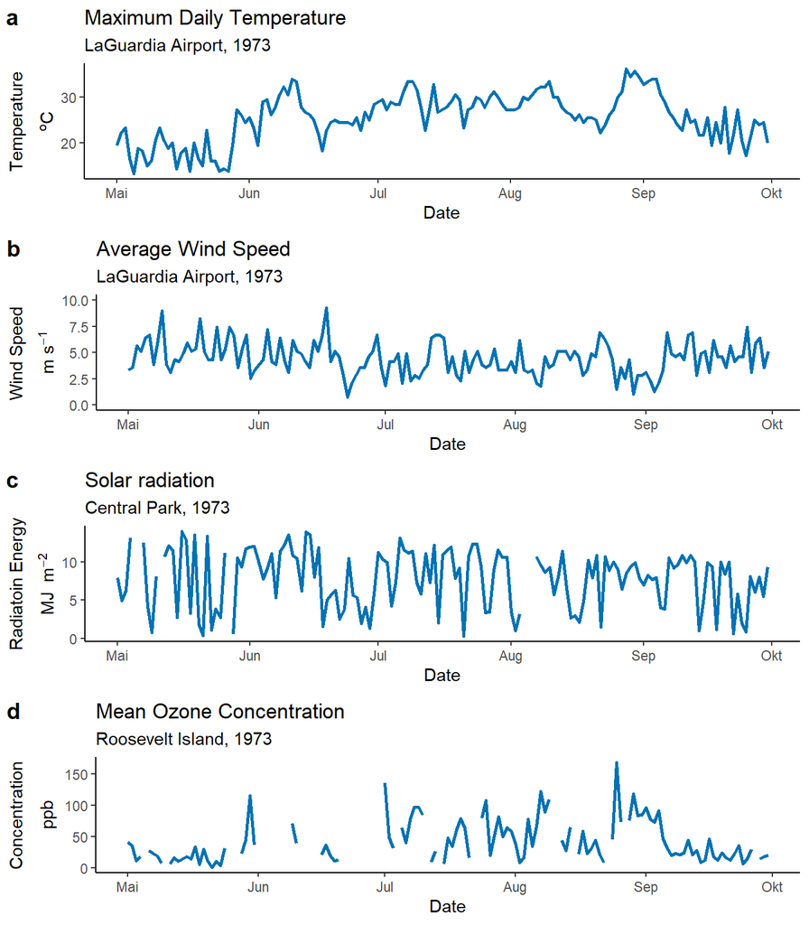

```r
# Ozon concentration plot
ozon_plot <- ggplot(
    data = airquality_SI,
    aes(x = date, y = Ozone)) +
  geom_line(color="#0072B2", linewidth=1) +
  labs(title = "Mean Ozone Concentration",
       subtitle = "Roosevelt Island, 1973",
       x = "Date",
       y = expression(atop("Concentration", "ppb"))) +
  theme_classic()

# Temperature plot
temp_plot <- ggplot(
    data = airquality_SI,
    aes(x = date, y = Temp)) +
  geom_line(color="#0072B2", linewidth=1) +
  labs(title = "Maximum Daily Temperature",
       subtitle = "LaGuardia Airport, 1973",
       x = "Date",
       y = expression(atop("Temperature", paste(""^o,"C")))) +
  theme_classic()


# Wind speed plot
wind_plot <- ggplot(
    data = airquality_SI,
    aes(x = date, y = Wind)) +
  geom_line(color="#0072B2", linewidth=1) +
  ylim(0, 10) +
  labs(title = "Average Wind Speed",
       subtitle = "LaGuardia Airport, 1973",
       x = "Date",
       y = expression(atop("Wind Speed", paste("m ", "s"^-1)))) +
  theme_classic()

# Wind speed plot
radiation_plot <- ggplot(
    data = airquality_SI,
    aes(x = date, y = Solar.R / 1e6)) +
  geom_line(color="#0072B2", linewidth=1) +
  labs(title = "Solar radiation",
       subtitle = "Central Park, 1973",
       x = "Date",
       y = expression(atop("Radiatoin Energy", paste("MJ ", " m"^-2)))) +
  theme_classic()

# Show the four plots
cowplot::plot_grid(temp_plot, wind_plot, radiation_plot, ozon_plot, ncol = 1, labels = "auto")
```

The four diagrams show the measured values for the whole period of time. Diagram **a** represents the temperature. The values are higher during the summer months from June to August compared to Mai and September. The measured wind speed, shown in diagram **b**, show that there is some wind on almost every day, covered by the data. The solar radiation in diagram **c** shows, some variation in the measured energy density. On a certain amount of days, it seems that the sky might have been covered by clouds and the measured energy was almost zero. Important from the ozone concentration in diagram **d** is the big number of missing values.

# Scatter plots and correlations

Representing the data as scatter plots and calculating the correlations between the different variables helps to understand the dependencies between them.

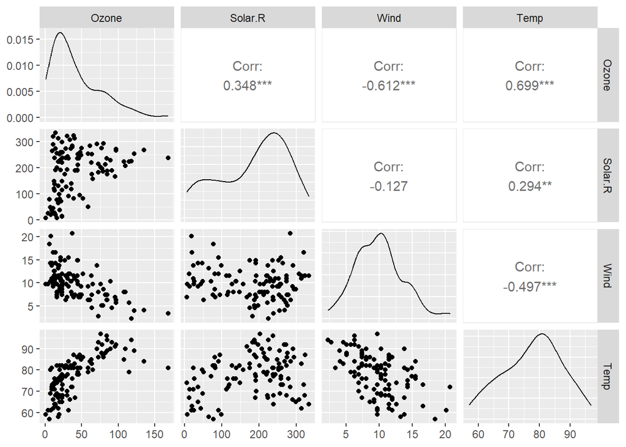

```r
# Pairwise scatter plots and correlation coefficients
ggpairs(na.omit(airquality), columns = 1:4, progress = FALSE)
```

The strongest correlation is calculated between temperature and ozone concentration. As described in the ozone formation chapter, the temperature is not directly involved in the ozone formation process and it’s not considered in the next diagrams.

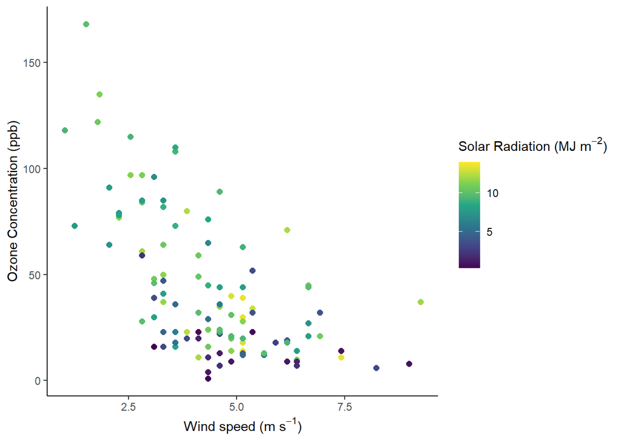

```r
# Scatter plot with colored points
ggplot(
  data = na.omit(airquality_SI),
  aes(x = Wind, y = Ozone, color = Solar.R / 1e6)) +
  geom_point(size = 2) +
  labs(x = expression(paste("Wind speed (m s"^-1, ")")),
       y = "Ozone Concentration (ppb)") +
  theme_classic() +
  scale_color_viridis_c(expression(paste("Solar Radiation (MJ m"^-2, ")")))
```

The diagram shows that high ozone concentrations occur in case of low wind speed and higher solar radiation.

# Linear model

```r
# Calculate linear regression model
linmod <- lm(Ozone ~ Wind + Solar.R, data = na.omit(airquality_SI))
summary(linmod)
```

```
##
## Call:
## lm(formula = Ozone ~ Wind + Solar.R, data = na.omit(airquality_SI))
##
## Residuals:
##     Min      1Q  Median      3Q     Max
## -45.651 -18.164  -5.959  18.514  85.237
##
## Coefficients:
##               Estimate Std. Error t value Pr(>|t|)
## (Intercept)  7.725e+01  9.068e+00   8.519 1.05e-13 ***
## Wind        -1.208e+01  1.506e+00  -8.024 1.34e-12 ***
## Solar.R      2.398e-06  6.280e-07   3.819 0.000224 ***
## ---
## Signif. codes:  0 '***' 0.001 '**' 0.01 '*' 0.05 '.' 0.1 ' ' 1
##
## Residual standard error: 24.92 on 108 degrees of freedom
## Multiple R-squared:  0.4495, Adjusted R-squared:  0.4393
## F-statistic: 44.09 on 2 and 108 DF,  p-value: 1.003e-14
```

The linear model, including the wind speed and the solar radiation as independent variables confirm the observed behavior from the previous graph. The mean ozone concentration is 12.08 ppb lower per m∙s<sup>-1</sup> wind speed, ceteris paribus. A higher solar radiation of 1 MJ∙m<sup>-2</sup> will increase the ozone concentration by 2.398 ppb in average, in case all other conditions stay constant. Both values are significant with a confidence level, lower than 0.1%.

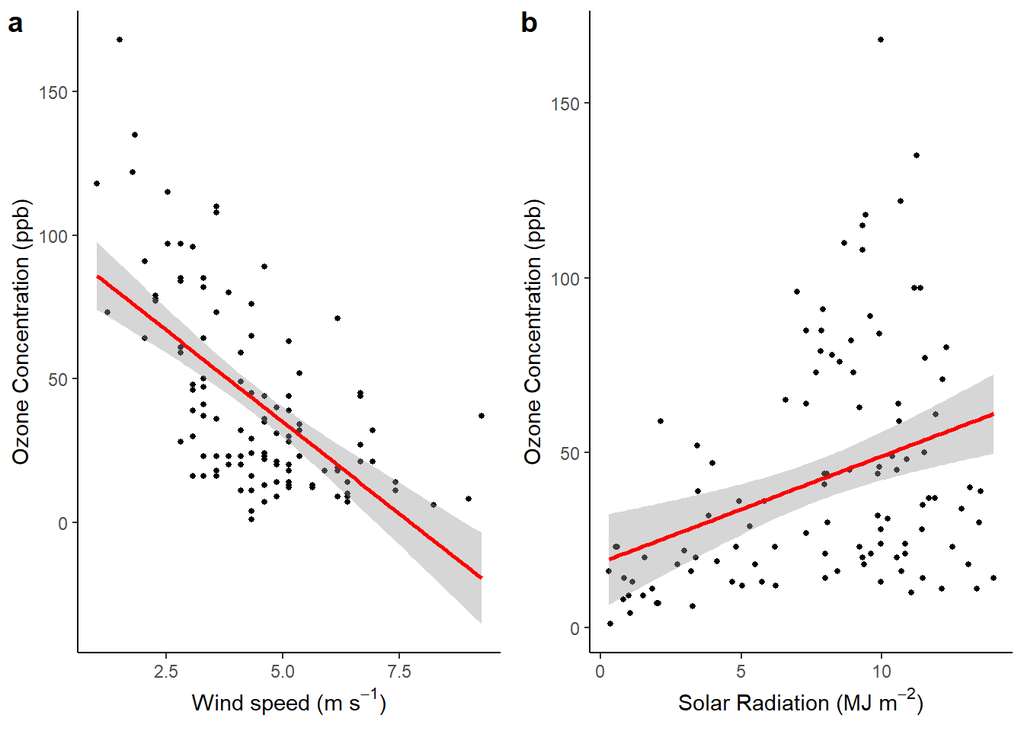

```r
# Linear regression for wind speed
wind_reg_plot <- ggplot(
  data = na.omit(airquality_SI),
  aes(x = Wind, y = Ozone)) +
  geom_point(size = 1) +
  geom_smooth(formula=y~x, method = "lm", color = "red", fullrange = TRUE) +
  labs(x = expression(paste("Wind speed (m s"^-1, ")")),
       y = "Ozone Concentration (ppb)") +
  theme_classic()


# Linear regression for solar radiation
rad_reg_plot <- ggplot(
  data = na.omit(airquality_SI),
  aes(x = Solar.R / 1e6, y = Ozone)) +
  geom_point(size = 1) +
  geom_smooth(formula=y~x, method = "lm", color = "red", fullrange = TRUE) +
  labs(x = expression(paste("Solar Radiation (MJ m"^-2, ")")),
       y = "Ozone Concentration (ppb)") +
  theme_classic()

# Show the four plots
cowplot::plot_grid(wind_reg_plot, rad_reg_plot, ncol = 2, labels = "auto")
```

The two graphs illustrate the linear regression for the two variables independently, graph **a** for the wind speed and graph **b** for the solar radiation. Plotting the ozone concentration against the solar radiation shows a high variance. The results from the linear regression models support both hypotheses.

# Frequency of high ozone concentrations

The World Health Organization (WHO) gives recommendations for long-term exposure to ozone in their Air Quality Guidelines (AQG) (WHO 2021). The definition of the critical value is quite complex. It is defined as the average of daily maximum 8-hour mean O<sub>3</sub> concentration in the six consecutive months with the highest six-month running-average O<sub>3</sub> concentration. (WHO 2021:103). For the data evaluation in this work, simply the final target level of 60 µg∙m<sup>-3</sup> is compared to the daily mean ozone concentration from the data set.

The conversion factors for ozone concentration at 20 °C and 1013 hPa is as follows: 1 mg∙m<sup>-3</sup> = 0.5011 ppm. (WHO 2021:98). In the diagrams, the limit is set to 30 ppb.

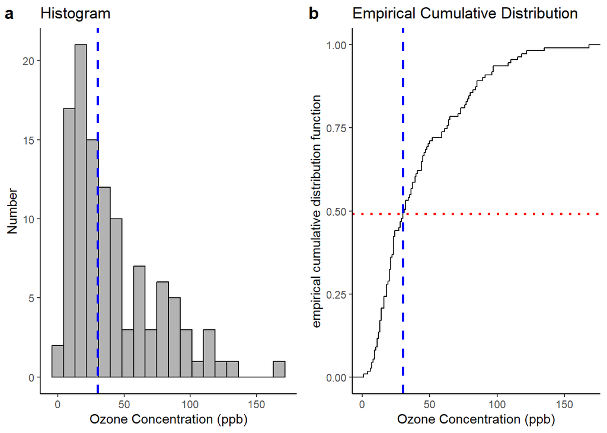

```r
# Plotting histogram of ozone concentration
hist_plot <- ggplot(
    data = na.omit(airquality_SI),
    aes(x = Ozone)
    ) +
  geom_histogram(bins = 20, fill = "grey70", color = "black") +
  geom_vline(aes(xintercept=30), color="blue", linetype="dashed", linewidth=1) +
  labs(title = "Histogram", x = "Ozone Concentration (ppb)", y = "Number" ) +
  theme_classic()

# Plotting the empirical cumulative distribution of the ozone concentratoin
ecdf_plot <- ggplot(
    data = na.omit(airquality_SI),
    aes(x = Ozone)
    ) +
  stat_ecdf(geom = "step") +
  geom_vline(aes(xintercept=30), color="blue", linetype="dashed", linewidth=1) +
  geom_hline(aes(yintercept=ecdf(airquality_SI$Ozone)(30)), color="red", linetype="dotted", linewidth=1) +
  labs(title = "Empirical Cumulative Distribution", x = "Ozone Concentration (ppb)", y = "empirical cumulative distribution function" ) +
  theme_classic()

# Show the four plots
cowplot::plot_grid(hist_plot, ecdf_plot, ncol = 2, labels = "auto")
```

The dashed blue line represents the recommended ozone concentration from the WHO. In New York, the measured ozone concentration was higher than the recommended levels almost every second day during the summer 1973.

# Literature

Chambers, J. M., Cleveland, W. S., Kleiner, B. and Tukey, P. A. (1983) Graphical Methods for Data Analysis. Belmont, CA: Wadsworth.

NIST (National Institute of Standards and Technology) Physical Measurement Laboratory 2016: NIST Guide to the SI, Appendix B.9: Factors for units listed by kind of quantity or field of science. https://www.nist.gov/pml/special-publication-811/nist-guide-si-appendix-b-conversion-factors/nist-guide-si-appendix-b9 (accessed on June 1<sup>st</sup>, 2023)

Wang, Tao, Likun Xue, Peter Brimblecombe, Yun Fat Lam, Li Li und Li Zhang 2017: Ozone pollution in China: A review of concentrations, meteorological influences, chemical precursors, and effects. Science of The Total Environment 575 : 1582–1596. DOI: https://doi.org/10.1016/j.scitotenv.2016.10.081

World Health Organization (WHO) (2021): WHO globalair quality guidelines.